# Example dataset creation and testing approach for qSIP package

Bram Stone

January 30, 2020

## Overview

- The qSIP package gives users the option to group their samples in a variety of ways
- These different grouping schemes each require different steps to properly calculate qSIP values and should be able to anticipate missing data and adjust calculations in ways that are reasonable to the user
- Thus, an example dataset will be created that incorporates multiple levels of grouping so that we can test the qSIP package code
- The output from the qSIP package will be compared to calculations made manually
- The example dataset will be modified from the Koch et al. 2018 paper in *Ecosphere*

## Example data scheme

|  | replicates | group | treatment | time |
| --- | --- | --- | --- | --- |
| A_0 | 3 | A | NA | 0 |
| B_0 | 3 | B | NA | 0 |
| A_16O_10 | 3 | A | <sup>16</sup>O | 10 |
| A_18O_10 | 3 | A | <sup>18</sup>O | 10 |
| B_16O_10 | 3 | B | <sup>16</sup>O | 10 |
| B_18O_10 | 3 | B | <sup>18</sup>O | 10 |
| A_16O_15 | 3 | A | <sup>16</sup>O | 15 |
| A_18O_15 | 3 | A | <sup>18</sup>O | 15 |
| B_16O_15 | 3 | B | <sup>16</sup>O | 15 |
| B_18O_15 | 3 | B | <sup>18</sup>O | 15 |

These data have multiple groups, and multiple timepoints. Each replicate has 12-18 fractions, as determined by the *Ecosphere* dataset.

## Data creation

### Read in *Ecosphere* data

```r
data_dir <- '~/Projects/Dimensions of Biodiversity qSIP scaling project/Data/Ecosphere 2018 data'
otu_file <- 'TM_uc_97_non_chimeras_otu_table_no_low_sample_filtered_.005%filtered_L6.txt'

# read in otu data (contains sample data)
otu_names <- scan(paste(data_dir, otu_file, sep='/'),
                  what=character(), nlines=1, sep='\t')
otu <-  scan(paste(data_dir, otu_file, sep='/'),
             what=character(), skip=1, sep='\t')
#
otu <- matrix(otu, ncol=length(otu_names), byrow=T)
colnames(otu) <- otu_names; rm(otu_names)

# get taxonomic data from OTU table
tax <- otu[,1]
names(tax) <- paste0('otu_', 1:length(tax))

# fix otu table
otu <- otu[,-1]
rownames(otu) <- names(tax)
storage.mode(otu) <- 'double'

# read in sample data and soil data
sam <- read.delim(paste(data_dir, 'TM_qSIP_Data.txt', sep='/'))
soil <- read.delim(paste(data_dir, 'TM_SoilExtractionData.txt', sep='/'))
```

### Fix data taxonomic data

```r
taxonomy <- read.table(text = tax, sep = ";",
                       fill = T, stringsAsFactors = F)
taxonomy <- sapply(taxonomy, function(x) sub("\\s?\\w{1}__", "", x, perl = T))
taxonomy[taxonomy=='' | taxonomy=='Other'] <- NA
colnames(taxonomy) <- c("Kingdom", "Phylum", "Class", "Order",
                        "Family", "Genus")
rownames(taxonomy) <- rownames(otu)
```

### Combine sample and soil data

```r
# create common ID column
sam$merging_ID <- with(sam, interaction(rep, tmt))
soil$merging_ID <- paste(rep(1:5,3), rep(c('Time0', '16O', '18O'), each=5), sep='.')

sam <- merge(sam, soil[,c('g.soil.extracted', 'g.soil.tube', 'merging_ID')], all.x=T)
sam$merging_ID <- NULL
```

### Combine sample and sample name data to match OTU table

```r
mapping <- read.delim(paste(data_dir, 'TM_mapping_file.txt', sep='/'))
sam$sample <- gsub('-', '.', sam$sample)
sam <- merge(mapping[,c('X.SampleID', 'sample.rep.fration', 'Description')], sam,
             by.y='sample', by.x='sample.rep.fration', all.y=T)
names(sam)[1:3] <- c('sample.rep.fraction', 'SampleID', 'RepID')
sam <- sam[,c(2,1,3:ncol(sam))]
rm(mapping)

# Can't have replicate IDs match across treatments
sam$RepID <- sub('C(.{1})', '\\1.t0', sam$RepID)

# Make time0 data NA in treatment column, add timepoint (10 day incubation)
sam$tmt <- ifelse(sam$tmt=='Time0', NA, as.character(sam$tmt))
sam$time <- ifelse(is.na(sam$tmt), 0, 10)

# Samples with NA for SampleID are not in OTU table - remove
# This amounts to a couple of 16O-18O fractions but mostly fractionated time 0 data
# (these were not sequenced, only the whole tubes/replicates at time 0 were)
sam <- sam[!is.na(sam$SampleID),]
sam <- sam[order(as.numeric(as.character(sam$SampleID))),]
sam <- sam[sam$SampleID %in% colnames(otu),]
rownames(sam) <- sam$SampleID

# Match OTU table sample order to sample data
otu <- otu[,match(sam$SampleID, colnames(otu))]

# remove extraneous columns
sam <- sam[,c('SampleID', 'sample.rep.fraction', 'RepID',
              'rep', 'tmt', 'density.g.ml',
              'qPCR.16S.copies.ul', 'time')]

# create fraction column
sam$fraction <- sub('(.*)\\.(\\d+)$', '\\2', sam$sample.rep.fraction)
sam$fraction[sam$time==0] <- NA
```

### Keep only first 20 OTUs

```r
otu <- otu[1:20,]
taxonomy <- taxonomy[1:20,]
```

### Duplicate data for groups A and B and for timepoint 15

```r
# first remove replicates 4 and 5 in each treatment
sam <- sam[!sam$rep %in% 4:5,]
otu <- otu[,match(sam$SampleID, colnames(otu))]

# duplicate dataset for groups A and B
sam <- list(A=sam, B=sam)
sam <- Map(function(x,y) {x$group <- y; x}, sam, names(sam))
# increase densities for 18O samples in group B
sam$B <- within(sam$B, {
  density.g.ml[tmt=='18O' & !is.na(tmt)] <- density.g.ml[tmt=='18O' & !is.na(tmt)] * 1.025
})
# combine
sam <- do.call(rbind, sam)

# duplicate dataset for timepoint 15
sam_15 <- sam[sam$time==10,]
# increase qPCR copies and modify timepoint
sam_15 <- within(sam_15, {
  qPCR.16S.copies.ul <- floor(qPCR.16S.copies.ul * 1.05)
  time <- 15
})
# combine
sam <- rbind(sam, sam_15)

# modify RepID and sample.rep.fraction to reflect new groupings
sam <- within(sam, {
  RepID <- paste(group, rep, tmt, time, sep='.')
  RepID <- sub('NA\\.', '', RepID)
  sample.rep.fraction <- paste(RepID, fraction, sep='.')
  sample.rep.fraction <- sub('\\.NA', '', sample.rep.fraction)
})

# duplicate values in OTU table
otu <- otu[,match(sam$SampleID, colnames(otu))]

# rename otu colnames, sam rownames, and sam$SampleID
sam$SampleID <- 1:nrow(sam)
rownames(sam) <- sam$sample.rep.fraction
colnames(otu) <- sam$sample.rep.fraction
```

### Create phylosphere object and long-form data frame

```r
# md for "mock data"
md <- phyloseq(otu_table(otu, taxa_are_rows=T),
               tax_table(taxonomy),
               sample_data(sam))

# create long-form data frame
mdl <- psmelt(md)
```

## Scheme for qSIP calculations

There are several binary decisions to make in how to group a qSIP data set. Each calculation will be given a designation based off binary numbers, with the largest (left-most) digit reponsible for the largest grouping decision. **Note:** To allow for the flexibility of these options, the ID code for each replicate (tube) *must* be 100% unique. It *cannot* be shared with *any* other replicate in any other time or group. Other than that, different requirements for sample matching and missing data apply to each situation.

### Enrichment

| Group | Label | Light |  | Meaning | Code |
| --- | --- | --- | --- | --- | --- |
| 0 | 0 | 0 |  | Average across groups, run with averaged label and averaged light values | 000 |
| 0 | 0 | 1 |  | Average across groups, run with averaged label and separate light values | 001 |
| 0 | 1 | 0 |  | Average across groups, run with separate label and averaged light values | 010 |
| 0 | 1 | 1 |  | Average across groups, run with separate label and separate light values | 011 |
| 1 | 0 | 0 |  | Average *per* group, run with averaged label and averaged light values | 100 |
| 1 | 0 | 1 |  | Average *per* group, run with averaged label and separate light values | 101 |
| 1 | 1 | 0 |  | Average *per* group, run with separate label and averaged light values | 110 |
| 1 | 1 | 1 |  | Average *per* group, run with separate label and separate light values | 111 |

### Growth

Similar but the with five binary digits (*e.g.*, 01101) where the right-most digit corresponds to whether different timepoints are to be analyzed sequentially, or each with respect to 0. Timepoints can’t be ignored in growth calculations, so separating them is more akin to separating heavy and light WADs (necessary) rather than averaging replicates or keeping them separate (user preference). The first digit designates whether grouping is specified; second designates averaging of labeled values; and third designates averaging of unlabeled values. The fourth digit specified whether or not abundances at time 0 are to be averaged or matched against labeled/unlabeled values. This leaves 32 total options.

| Group | Label | Light | Time<sub>0</sub> | Sequential time |
| --- | --- | --- | --- | --- |
| 0:1 | 0:1 | 0:1 | 0:1 | 0:1 |

## Testing WADs

The calculation codes don’t apply to the WADs. With the exception of filtering, which is not done here, WAD values are calculated one way. Note that it was important to re-relativize the abundances of the 20 taxa. In the qsip package code, this is the default action. Since abundances were already relativized, and most taxa were removed prior to the calculation, it is important to not skip this step.

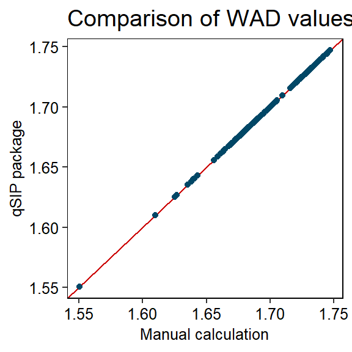

## Testing MWs

Here the calculation codes begin to take effect as grouping begins to take place.

For calculation code `011`, it was necessary to create a replicate numbering column that matched each <sup>18</sup>O sample to it’s corresponding <sup>16</sup>O sample. For example, sample `A.1.16O.10` must have the same replicate number as `A.1.18O.10`. With three samples, two groups, and two timepoints, that generated a replicate number from 1 to 12.

For calculation code `111`, Replicate matching was from 1 to 6, since the replicates are grouped into `A` and `B`. Note that this groups together the 10 and 15 timepoints.

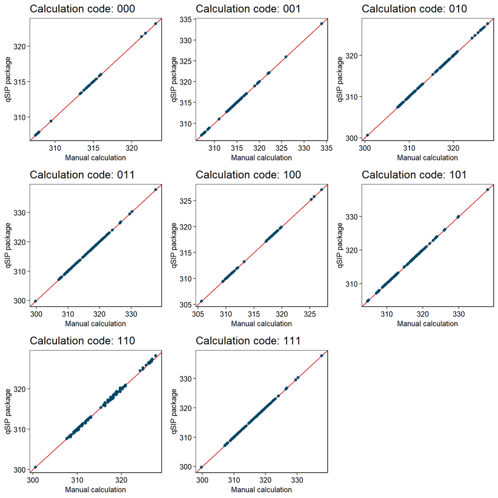

## Testing isotope excess

Calculation of excess atom fraction (EAF/AEF/AFE). The same replicate matching details apply to these calculations as well as molecular weight calculations

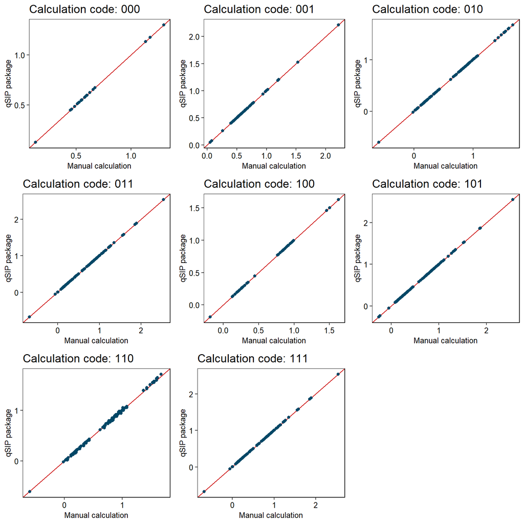